# Ciência de Dados

Limpeza e Tratamento de Dados - Churn

Danielle Figueiredo

30/03/2021

*Observação: A função `knitr::kable()` é usada nesse documento para que uma versão mais apresentável da tabela de dados seja vista no arquivo HTML. Algumas alternativas para tabelas podem ser encontradas nesse [link](https://gomesfellipe.github.io/post/2018-01-12-tabelas-incriveis-com-r/tabelas-incriveis-com-r/).*

## Ambientação dos Dados

O conjunto de dados trabalhados neste documento trata da rotatividade de clientes. Com base nisso, pretendemos criar um modelo que prediga se um cliente possui ou não o perfil de quem cancelará o contrato.

## Import de Dados

Como o conjunto de dados está em uma pasta diferente do código, utilizamos a função `file.choose()` para escolher o caminho do arquivo através de uma caixa de diálogo.

A função `read.csv()` permite a leitura do arquivo e alguns argumentos deste função foram utilizados para manipulação dos dados, como:

- `sep` - identifica o caractere separador do arquivo (por *default*, o separador é uma vírgula)
- `na.strings` - troca os valores ‘NA’ identificado pelo R (o equivalente a *null* do banco de dados) por uma string determinada
- `stringsAsFactors` - identifica as strings com a classe *Factor*, o que restringe o campo de informação para algumas possibilidades

```r
dados = read.csv( file.choose(), sep = ";", na.strings = "", stringsAsFactors = TRUE )
knitr::kable( head(dados) )
```

| X0 | X1 | X2 | X3 | X4 | X4.1 | X6 | X7 | X8 | X9 | X10 | X11 |
| --- | --- | --- | --- | --- | --- | --- | --- | --- | --- | --- | --- |
| 1 | 619 | RS | Feminino | 42 | 2 | 0 | 1 | 1 | 1 | 10134888 | 1 |
| 2 | 608 | SC | Feminino | 41 | 1 | 8380786 | 1 | 0 | 1 | 11254258 | 0 |
| 3 | 502 | RS | Feminino | 42 | 8 | 1596608 | 3 | 1 | 0 | 11393157 | 1 |
| 4 | 699 | RS | Feminino | 39 | 1 | 0 | 2 | 0 | 0 | 9382663 | 0 |
| 5 | 850 | SC | Feminino | 43 | 2 | 12551082 | 1 | 1 | 1 | 790841 | 0 |
| 6 | 645 | SC | Masculino | 44 | 8 | 11375578 | 2 | 1 | 0 | 14975671 | 1 |

## Resumo dos dados

O resumo dos dados nos ajuda a indentificar as principais medidas para as variáveis numéricas e oferece um resumo da abrengencia das variáveis qualitativas.

```r
summary(dados)
```

```
##        X0               X1         X2              X3            X4
##  Min.   :   1.0   Min.   :376.0   PR:257   F        :  2   Min.   :-20.0
##  1st Qu.: 251.5   1st Qu.:580.0   RP:  1   Fem      :  1   1st Qu.: 32.0
##  Median : 501.0   Median :653.0   RS:478   Feminino :461   Median : 37.0
##  Mean   : 500.9   Mean   :648.6   SC:258   M        :  6   Mean   : 38.9
##  3rd Qu.: 750.5   3rd Qu.:721.0   SP:  4   Masculino:521   3rd Qu.: 44.0
##  Max.   :1000.0   Max.   :850.0   TD:  1   NA's     :  8   Max.   :140.0
##
##       X4.1              X6                 X7              X8
##  Min.   : 0.000   Min.   :       0   Min.   :1.000   Min.   :0.0000
##  1st Qu.: 2.000   1st Qu.:       0   1st Qu.:1.000   1st Qu.:0.0000
##  Median : 5.000   Median : 8958835   Median :1.000   Median :1.0000
##  Mean   : 5.069   Mean   : 7164928   Mean   :1.527   Mean   :0.7027
##  3rd Qu.: 8.000   3rd Qu.:12586844   3rd Qu.:2.000   3rd Qu.:1.0000
##  Max.   :10.000   Max.   :21177431   Max.   :4.000   Max.   :1.0000
##
##        X9              X10                 X11
##  Min.   :0.0000   Min.   :9.677e+03   Min.   :0.0000
##  1st Qu.:0.0000   1st Qu.:3.029e+06   1st Qu.:0.0000
##  Median :1.0000   Median :8.703e+06   Median :0.0000
##  Mean   :0.5095   Mean   :3.529e+07   Mean   :0.2032
##  3rd Qu.:1.0000   3rd Qu.:1.405e+07   3rd Qu.:0.0000
##  Max.   :1.0000   Max.   :1.193e+10   Max.   :1.0000
##                   NA's   :7
```

## Nomear as colunas

É comum que os dados não possuam identificação para as colunas, por isso é necessário saber adicioná-los manualmente.

```r
colnames(dados) = c('id', 'score', 'estados', 'generos', 'idade', 'patrimonio', 'saldo',
                    'produtos', 'temCartaoCredito', 'ativo', 'salario', 'saiu')
knitr::kable( head(dados) )
```

| id | score | estados | generos | idade | patrimonio | saldo | produtos | temCartaoCredito | ativo | salario | saiu |
| --- | --- | --- | --- | --- | --- | --- | --- | --- | --- | --- | --- |
| 1 | 619 | RS | Feminino | 42 | 2 | 0 | 1 | 1 | 1 | 10134888 | 1 |
| 2 | 608 | SC | Feminino | 41 | 1 | 8380786 | 1 | 0 | 1 | 11254258 | 0 |
| 3 | 502 | RS | Feminino | 42 | 8 | 1596608 | 3 | 1 | 0 | 11393157 | 1 |
| 4 | 699 | RS | Feminino | 39 | 1 | 0 | 2 | 0 | 0 | 9382663 | 0 |
| 5 | 850 | SC | Feminino | 43 | 2 | 12551082 | 1 | 1 | 1 | 790841 | 0 |
| 6 | 645 | SC | Masculino | 44 | 8 | 11375578 | 2 | 1 | 0 | 14975671 | 1 |

## Transformando em Data Frame

A classe de dados que melhor se adequa aos conjuntos de dados no R, são os data frames, por isso converteremos a tabela.

```r
dados = data.frame(dados)
knitr::kable( head(dados) )
```

| id | score | estados | generos | idade | patrimonio | saldo | produtos | temCartaoCredito | ativo | salario | saiu |
| --- | --- | --- | --- | --- | --- | --- | --- | --- | --- | --- | --- |
| 1 | 619 | RS | Feminino | 42 | 2 | 0 | 1 | 1 | 1 | 10134888 | 1 |
| 2 | 608 | SC | Feminino | 41 | 1 | 8380786 | 1 | 0 | 1 | 11254258 | 0 |
| 3 | 502 | RS | Feminino | 42 | 8 | 1596608 | 3 | 1 | 0 | 11393157 | 1 |
| 4 | 699 | RS | Feminino | 39 | 1 | 0 | 2 | 0 | 0 | 9382663 | 0 |
| 5 | 850 | SC | Feminino | 43 | 2 | 12551082 | 1 | 1 | 1 | 790841 | 0 |
| 6 | 645 | SC | Masculino | 44 | 8 | 11375578 | 2 | 1 | 0 | 14975671 | 1 |

## Análise Exploratória de Dados

### 1. Variáveis categóricas

- Estados

```r
counts = table( dados$estados )
counts
```

```
##
##  PR  RP  RS  SC  SP  TD
## 257   1 478 258   4   1
```

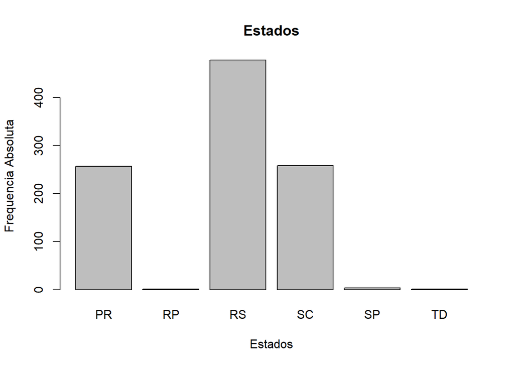

```r
barplot( counts, main = "Estados", xlab = "Estados", ylab = "Frequencia Absoluta")
```

É possível observar que os estados mais expressívos para o negócio são: PR (Paraná), RS (Rio Grande do Sul) e SC (Santa Catarina). Para os demais estados, a proporção em que são encontradas é indício de que pode afetar o modelo.

- Gêneros

```r
counts = table( dados$generos )
counts
```

```
##
##         F       Fem  Feminino         M Masculino
##         2         1       461         6       521
```

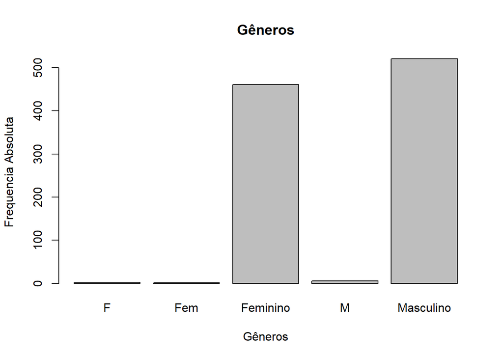

```r
barplot( counts, main = "Gêneros", xlab = "Gêneros", ylab = "Frequencia Absoluta")
```

Já para os dados de gênero, podemos observar a multiplicidade de categorias que possuem o mesmo significado.

### 2. Variáveis quantitativas

- Score

```r
summary( dados$score )
```

```
##    Min. 1st Qu.  Median    Mean 3rd Qu.    Max.
##   376.0   580.0   653.0   648.6   721.0   850.0
```

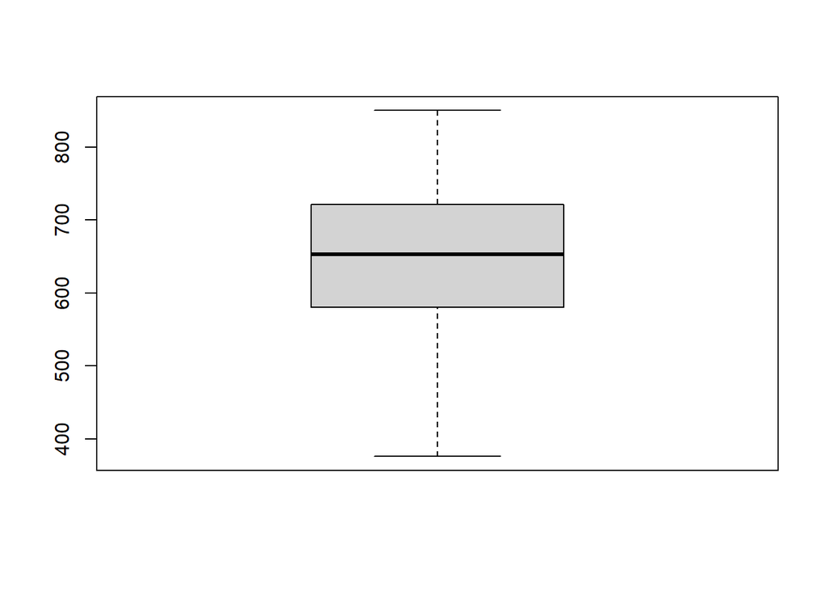

```r
boxplot( dados$score )
```

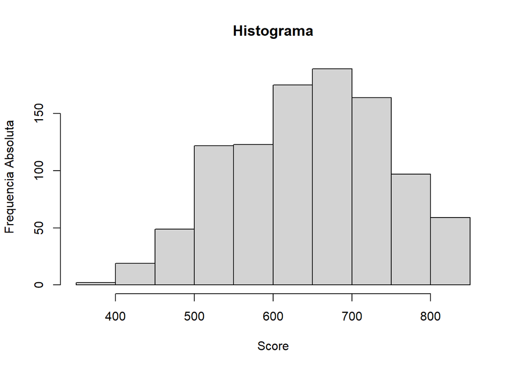

```r
hist( dados$score , main = "Histograma", xlab = "Score", ylab = "Frequencia Absoluta")
```

Score é a pontuação de crédito do cliente. Então, além de verificar o domínio em que esta pontuação está inserida (entre 0 e 1000), podemos observar o comportamento dos dados. Não foi encontrada anormalidade nessa coluna.

- Idade

```r
summary( dados$idade )
```

```
##    Min. 1st Qu.  Median    Mean 3rd Qu.    Max.
##   -20.0    32.0    37.0    38.9    44.0   140.0
```

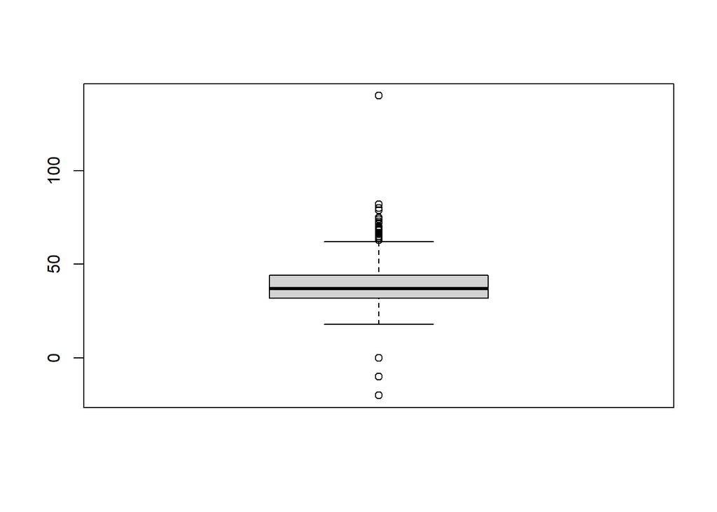

```r
boxplot( dados$idade )
```

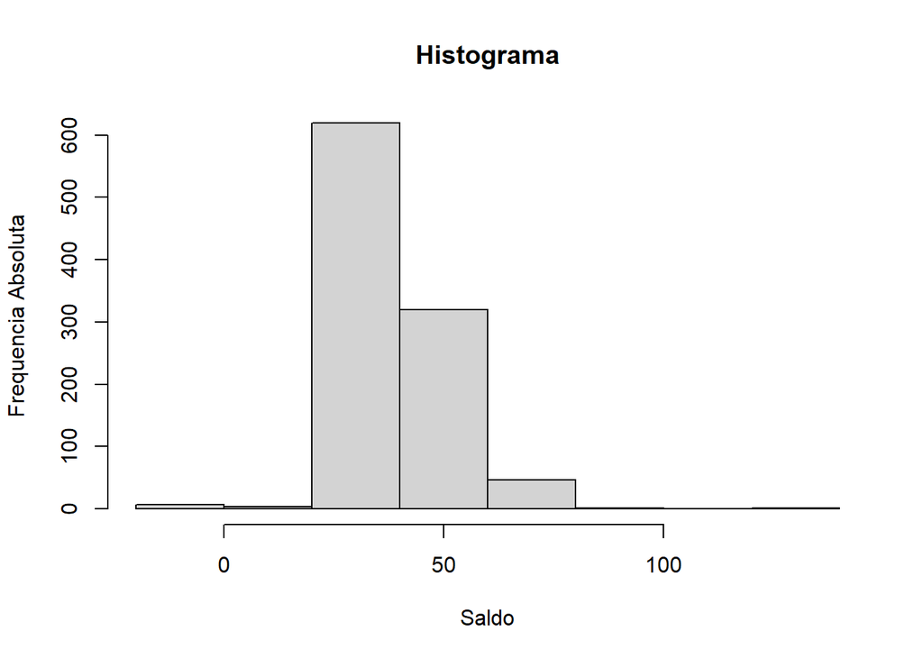

```r
hist( dados$idade , main = "Histograma", xlab = "Saldo", ylab = "Frequencia Absoluta")
```

Quanto ao domínio da idade, podemos observar que existem dados que precisam ser tratados, uma vez que uma pessoa não pode ter idade negativa e que é quase impossível que alguém viva até os 140 anos (confirmados pelo *boxplot*). Entretanto, os quartis mostram que há conformidade na maioria dos dados.

- Saldo

```r
summary( dados$saldo/1000000 )
```

```
##    Min. 1st Qu.  Median    Mean 3rd Qu.    Max.
##   0.000   0.000   8.959   7.165  12.587  21.177
```

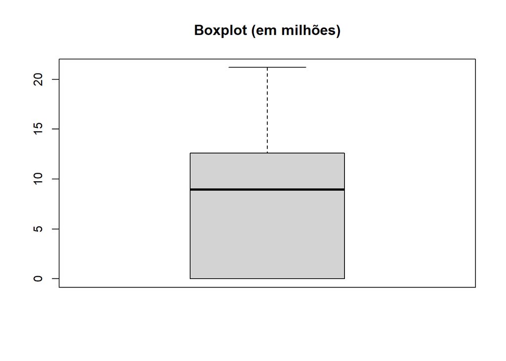

```r
boxplot( dados$saldo/1000000, main = "Boxplot (em milhões)" )
```

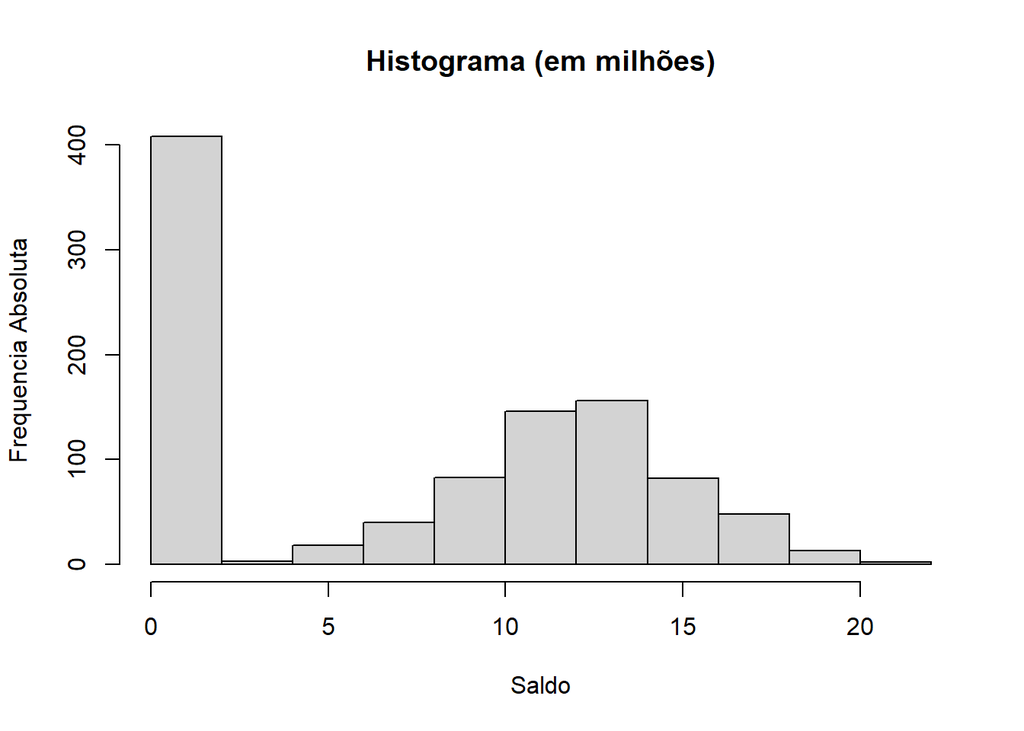

```r
hist( dados$saldo/1000000 , main = "Histograma (em milhões)", xlab = "Saldo", ylab = "Frequencia Absoluta")
```

Há uma expressividade de pessoas com saldo zerado, mas em geral os dados estão em conformidade com o esperado.

- Salário

```r
summary( dados$salario/1000000000 )
```

```
##      Min.   1st Qu.    Median      Mean   3rd Qu.      Max.      NA's
##  0.000010  0.003029  0.008703  0.035288  0.014052 11.934688         7
```

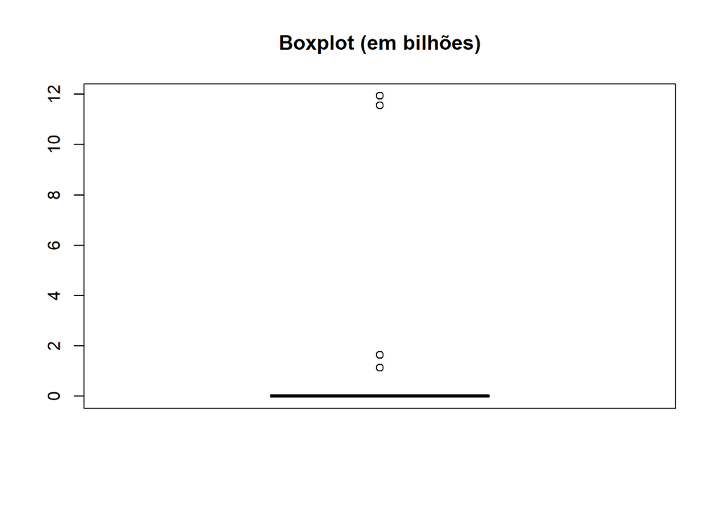

```r
boxplot( dados$salario/1000000000 , main = "Boxplot (em bilhões)" )
```

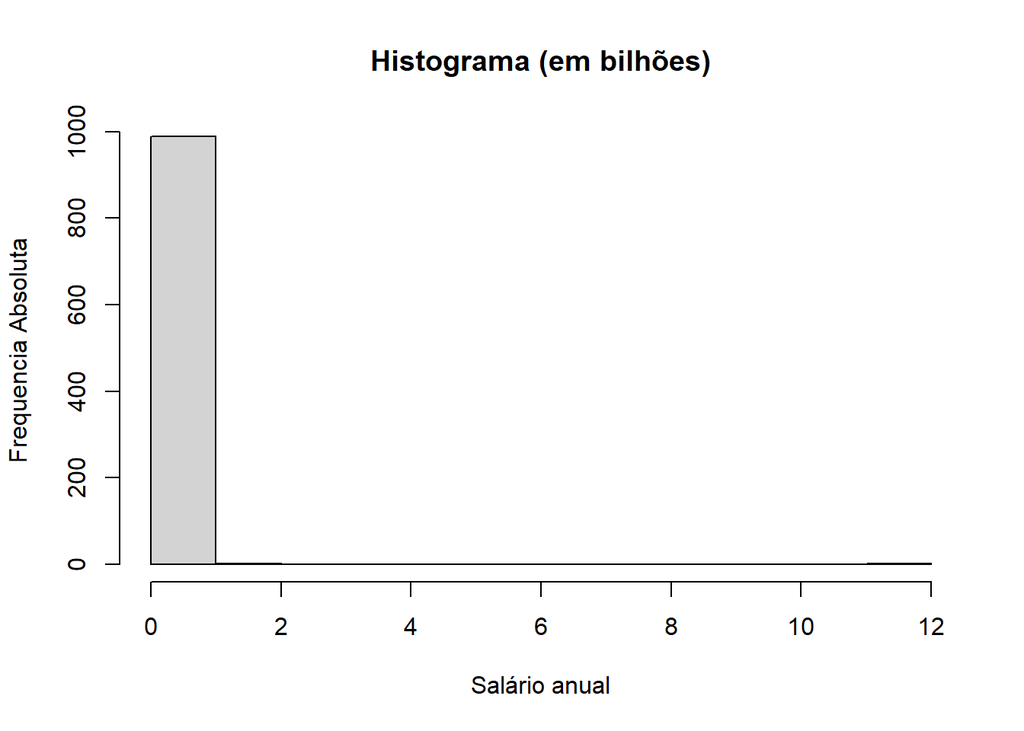

```r
hist( dados$salario/1000000000 , main = "Histograma (em bilhões)", xlab = "Salário anual", ylab = "Frequencia Absoluta")
```

Nessa colunas temos valores do tipo ‘NA’ que não são aceitos em modelos matemáticos, por isso precisa de tratamento.

## Tratamento de Dados

### 1. Valores nulos - NAs

```r
# Obtendo as linhas em que faltam valores em alguma coluna
knitr::kable( dados[ !complete.cases( dados ), ] )
```

|  | id | score | estados | generos | idade | patrimonio | saldo | produtos | temCartaoCredito | ativo | salario | saiu |
| --- | --- | --- | --- | --- | --- | --- | --- | --- | --- | --- | --- | --- |
| 18 | 18 | 549 | SC | Feminino | 24 | 9 | 0 | 2 | 1 | 1 | NA | 0 |
| 53 | 53 | 788 | RS | Feminino | 33 | 5 | 0 | 2 | 0 | 0 | NA | 0 |
| 65 | 65 | 603 | PR | NA | 26 | 4 | 10916637 | 1 | 1 | 1 | 9284067 | 0 |
| 85 | 86 | 493 | RS | NA | 46 | 4 | 0 | 2 | 1 | 0 | 190766 | 0 |
| 180 | 181 | 754 | PR | Feminino | 55 | 3 | 16160881 | 1 | 1 | 0 | NA | 1 |
| 214 | 215 | 676 | RS | NA | 34 | 1 | 6309501 | 1 | 1 | 1 | 4064581 | 0 |
| 297 | 298 | 714 | RS | NA | 31 | 4 | 12516926 | 1 | 1 | 1 | 10663689 | 0 |
| 331 | 332 | 656 | RS | Masculino | 50 | 7 | 0 | 2 | 0 | 1 | NA | 0 |
| 371 | 372 | 801 | SC | NA | 42 | 4 | 14194767 | 1 | 1 | 1 | 1059829 | 0 |
| 427 | 428 | 492 | PR | Masculino | 39 | 10 | 12457665 | 2 | 1 | 0 | NA | 0 |
| 502 | 503 | 692 | RS | NA | 54 | 5 | 0 | 2 | 1 | 1 | 8872184 | 0 |
| 551 | 552 | 721 | PR | Feminino | 36 | 3 | 6525307 | 2 | 1 | 0 | NA | 0 |
| 964 | 965 | 529 | SC | NA | 63 | 4 | 9613411 | 3 | 1 | 0 | 10873296 | 1 |
| 970 | 971 | 649 | PR | NA | 70 | 9 | 11685471 | 2 | 0 | 1 | 10712579 | 0 |
| 984 | 985 | 614 | PR | Feminino | 35 | 6 | 12810028 | 1 | 0 | 0 | NA | 1 |

A forma mais usual de tratamento para valores faltantes é substituição por valores característicos que mais aparecem (moda) ou por aqueles que resumem os dados (média ou mediana). Ou seja, para variáveis quantitativas, podemos substituir os NA’s pelo valor da mediana e, para variáveis qualitativas, pelo valor mais frequente.

```r
# mediana do salário
median( dados$salario, na.rm = TRUE )
```

```
## [1] 8703250
```

```r
# atribuir mediana aos valores faltantes
dados[ is.na( dados$salario ), ]$salario = median( dados$salario, na.rm = TRUE )
# Verificando as linhas em que faltam valores em alguma coluna
knitr::kable( dados[ !complete.cases( dados ), ] )
```

|  | id | score | estados | generos | idade | patrimonio | saldo | produtos | temCartaoCredito | ativo | salario | saiu |
| --- | --- | --- | --- | --- | --- | --- | --- | --- | --- | --- | --- | --- |
| 65 | 65 | 603 | PR | NA | 26 | 4 | 10916637 | 1 | 1 | 1 | 9284067 | 0 |
| 85 | 86 | 493 | RS | NA | 46 | 4 | 0 | 2 | 1 | 0 | 190766 | 0 |
| 214 | 215 | 676 | RS | NA | 34 | 1 | 6309501 | 1 | 1 | 1 | 4064581 | 0 |
| 297 | 298 | 714 | RS | NA | 31 | 4 | 12516926 | 1 | 1 | 1 | 10663689 | 0 |
| 371 | 372 | 801 | SC | NA | 42 | 4 | 14194767 | 1 | 1 | 1 | 1059829 | 0 |
| 502 | 503 | 692 | RS | NA | 54 | 5 | 0 | 2 | 1 | 1 | 8872184 | 0 |
| 964 | 965 | 529 | SC | NA | 63 | 4 | 9613411 | 3 | 1 | 0 | 10873296 | 1 |
| 970 | 971 | 649 | PR | NA | 70 | 9 | 11685471 | 2 | 0 | 1 | 10712579 | 0 |

### 2. Falta de padronização

Quando há falta de padronização, precisamos descobrir o domínio dos dados e então, restringir o domínio segundo a significância dos dados ou dos valores que mais aparecem. Para então os converter em *Fatores*, já que os modelos matemáticos não consideram variáveis categóricas propriamente ditas, mas seus *níveis*.

```r
# Quais as categorias existente na coluna
unique( dados$generos )
```

```
## [1] Feminino  Masculino M         <NA>      F         Fem
## Levels: F Fem Feminino M Masculino
```

```r
# Descobrindo os principais valores
summary( dados$generos )
```

```
##         F       Fem  Feminino         M Masculino      NA's
##         2         1       461         6       521         8
```

```r
# Padronizando
dados[ is.na( dados$generos ) | dados$generos == "M", ]$generos = "Masculino"
dados[ dados$generos == "F" | dados$generos == "Fem", ]$generos = "Feminino"
# Verificar resultados
summary( dados$generos )
```

```
##         F       Fem  Feminino         M Masculino
##         0         0       464         0       535
```

```r
# Remover os fatores  não utilizados
dados$generos = factor( dados$generos )
# Verifica se os níveis foram removidos
summary( dados$generos )
```

```
##  Feminino Masculino
##       464       535
```

### 3. Dados fora do domínio

Assim como fizemos com os valores faltantes, substituiremos as linhas que apresentam valores fora do domínio pela mediana.

- variáveis quantitativas

```r
# Verificando os dados
summary( dados$idade )
```

```
##    Min. 1st Qu.  Median    Mean 3rd Qu.    Max.
##   -20.0    32.0    37.0    38.9    44.0   140.0
```

```r
# Quais as linhas em que a idade está fora do intervalo aceitável
# Definimos intervalo aceitável entre 0 e 110 anos
knitr::kable( dados[ dados$idade < 0 | dados$idade > 110, ] )
```

|  | id | score | estados | generos | idade | patrimonio | saldo | produtos | temCartaoCredito | ativo | salario | saiu |
| --- | --- | --- | --- | --- | --- | --- | --- | --- | --- | --- | --- | --- |
| 868 | 869 | 636 | RS | Feminino | -10 | 1 | 17083346 | 1 | 1 | 0 | 11051028 | 1 |
| 985 | 986 | 773 | RS | Masculino | -20 | 1 | 12453278 | 2 | 0 | 1 | 1172357 | 0 |
| 991 | 992 | 655 | RS | Masculino | 140 | 5 | 93147 | 2 | 1 | 0 | 6621413 | 0 |

```r
# Existem dados nulos?
summary( is.na( dados$idade ) )
```

```
##    Mode   FALSE
## logical     999
```

```r
# Substituição
dados[ dados$idade < 0 | dados$idade > 110, ]$idade = median( dados$idade )
# Verificando a substituição
summary( dados$idade )
```

```
##    Min. 1st Qu.  Median    Mean 3rd Qu.    Max.
##     0.0    32.0    37.0    38.9    44.0    82.0
```

- variáveis qualitativas

```r
# Verifica as categorias
unique( dados$estados )
```

```
## [1] RS SC PR RP SP TD
## Levels: PR RP RS SC SP TD
```

```r
# Descobrir qual das categorias é a mais comum
summary( dados$estados )
```

```
##  PR  RP  RS  SC  SP  TD
## 257   1 478 258   4   1
```

```r
# Preencher trocar os que tiverem menor frequencia para o maior grupo
dados[ !dados$estados %in% c("RS", "SC", "PR"), ]$estados = "RS"
# Verificando as categorias
summary( dados$estados )
```

```
##  PR  RP  RS  SC  SP  TD
## 257   0 484 258   0   0
```

```r
# Eliminando os níveis zerados
dados$estados = factor( dados$estados )
# Nova verificação
summary( dados$estados )
```

```
##  PR  RS  SC
## 257 484 258
```

Note que nem sempre a melhor opção é juntar todos as classificações no maior grupo. A escolha dependerá muito mais do tipo de negócio e como os grupos se comportam. Para esse caso em específico, o estado do Rio Grande do Sul possui uma proporção muito maior do que as demais, o que pode justificar a escolha feita.

### 4. Dados duplicados

```r
# verificando duplicidade
x = dados[ duplicated( dados$id ), ]
knitr::kable( x )
```

|  | id | score | estados | generos | idade | patrimonio | saldo | produtos | temCartaoCredito | ativo | salario | saiu |
| --- | --- | --- | --- | --- | --- | --- | --- | --- | --- | --- | --- | --- |
| 82 | 81 | 665 | RS | Feminino | 34 | 1 | 9664554 | 2 | 0 | 0 | 17141366 | 0 |

```r
# Excluir a linha duplicada pelo índice
dados = dados[ -c(82), ]
# Verificar exclusão
x = dados[ duplicated( dados$id ), ]
x$id
```

```
## integer(0)
```

### 5. Outliers

A pergunta principal a ser respondida é: que métrica usar para representar a uma conformidade dos dados? Em geral, podemos utilizar o desvio padrão.

```r
# criando um parâmetro: desvio-padrão
desv = sd( dados$salario, na.rm = TRUE)
# dados não conformes a padronização
knitr::kable( dados[ dados$salario >= 2*desv, ] )
```

|  | id | score | estados | generos | idade | patrimonio | saldo | produtos | temCartaoCredito | ativo | salario | saiu |
| --- | --- | --- | --- | --- | --- | --- | --- | --- | --- | --- | --- | --- |
| 8 | 8 | 376 | PR | Feminino | 29 | 4 | 11504674 | 4 | 1 | 0 | 11934688000 | 1 |
| 117 | 118 | 668 | PR | Feminino | 37 | 6 | 1678644 | 1 | 1 | 0 | 11563829000 | 0 |
| 171 | 172 | 484 | RS | Feminino | 29 | 4 | 13011439 | 1 | 1 | 0 | 1640178900 | 0 |
| 231 | 232 | 673 | RS | Masculino | 72 | 1 | 0 | 2 | 0 | 1 | 1119811900 | 0 |

Forma alternativa, que não considera os NA’s:

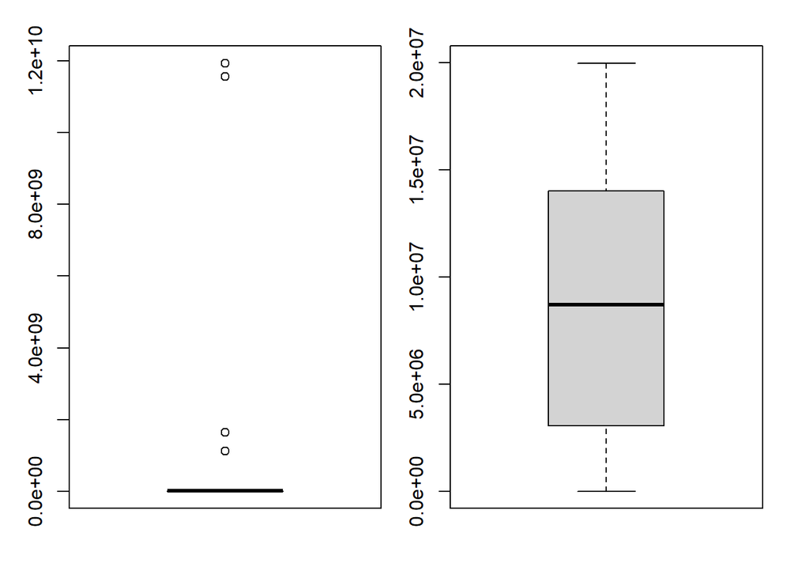

```r
par( mfrow = c(1, 2), oma = c(1, 1, 1, 1), mar = c(2, 2, 1, 1) )
boxplot( dados$salario )
boxplot( dados$salario , outline = FALSE )
```

O gráfico acima mostra que a diferença dos dados quando removemos os pontos considerados outliers (*pontos fora da curva*).

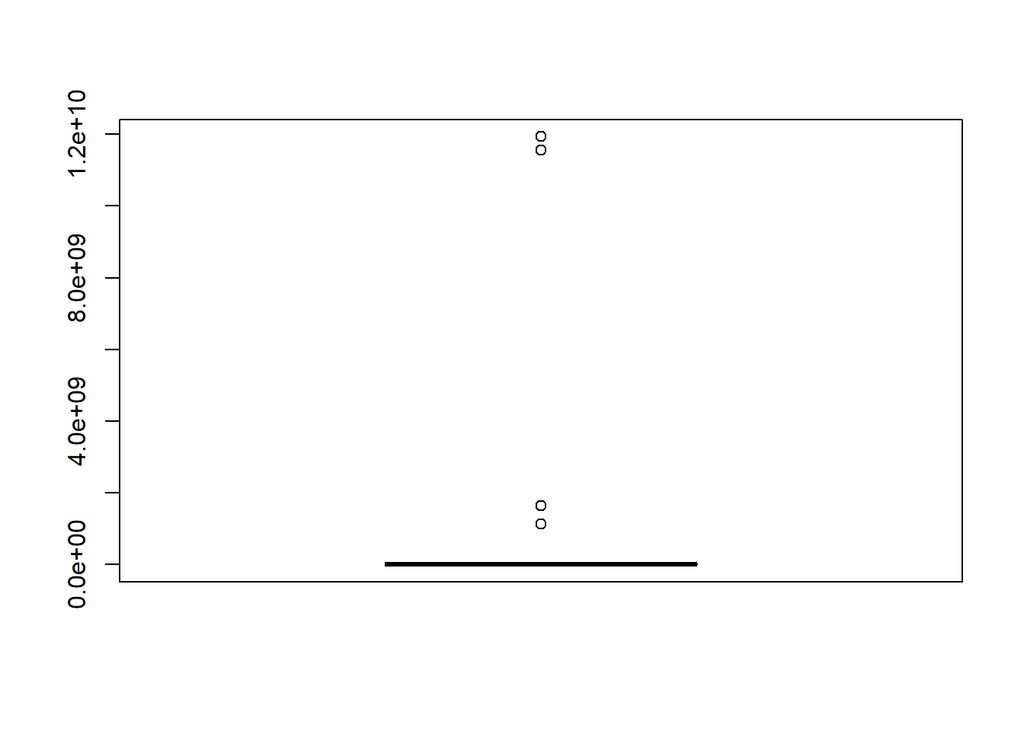

```r
x = boxplot( dados$salario )$out
```

```r
x
```

```
## [1] 11934688000 11563829000  1640178900  1119811900
```

```r
# Atualizamos os outliers para o valor da mediana
dados[ dados$salario >= 2*desv, ]$salario = median( dados$salario )
# Verificação
dados[ dados$salario >= 2*desv, ]$salario
```

```
## numeric(0)
```